# Data Wrangling in the `tidyverse`

Alexander Poon Andrew Marsee andrew.marsee@tn.gov

November 14, 2020

## Table of contents

- Looking at a data frame
- Keeping/dropping columns
- Reordering columns
- Keeping/dropping observations
- Creating/modifying columns
- Creating/modifying columns conditionally
- The pipe operator
- Renaming columns
- Sorting
- Creating a data frame of summary statistics
- Aggregating data by group
- Add summary statistics to a data frame
- Operations by row
- Combining data frames
- Reshaping

## The `tidyverse`

The `tidyverse` is a set of packages which covers most steps of the data science process (importing, wrangling, visualization).

[figure not shown]

- Built around the concept of a **tidy** data frame
- Work nicely with the **pipe** `%>%`

## Obtaining the `tidyverse`

Install the `tidyverse` packages and dependencies:

```r
install.packages("tidyverse")
```

Import the core `tidyverse` packages into your R session:

```r
library(tidyverse)
```

## Reading in data

Use `readr::read_csv()` to import a .csv file:

```r
districts <- read_csv("data/districts.csv")
```

## Our data

For each of 145 school districts and the State, the `districts` data contains:

- Proficiency rates on state tests
- Student demographics
- Chronic absenteeism
- Discipline (suspension, expulsion) rates
- High school graduation, dropout rates
- Average ACT composite scores
- A region in Tennessee

for the 2014-15 school year.

## Looking at data

Use `View()` to look at a data frame:

```r
View(districts)
```

## Looking at data

The RStudio viewer has features for sorting and filtering:

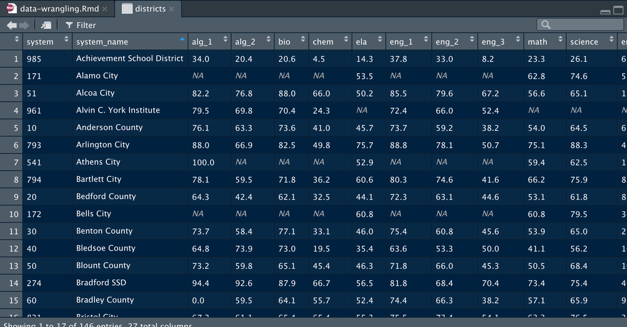

## Looking at data

The RStudio viewer has features for sorting and filtering:

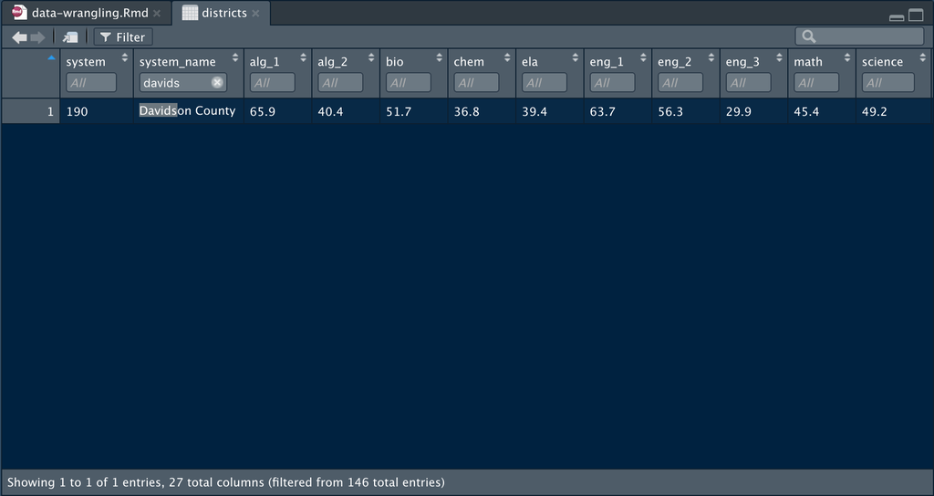

## An overview of a data frame

Use `summary()` to get an overview of a data frame:

```r
summary(districts)
```

```
##      system      system_name            alg_1
##  Min.   :  0.0   Length:146         Min.   : 22.90
##  1st Qu.:212.5   Class :character   1st Qu.: 63.20
##  Median :485.0   Mode  :character   Median : 73.10
##  Mean   :480.5                      Mean   : 70.92
##  3rd Qu.:757.8                      3rd Qu.: 79.50
##  Max.   :985.0                      Max.   :100.00
##                                     NA's   :21
##      alg_2            bio              chem
##  Min.   :14.70   Min.   : 11.80   Min.   :14.30
##  1st Qu.:44.30   1st Qu.: 59.30   1st Qu.:33.85
##  Median :57.90   Median : 68.90   Median :44.20
##  Mean   :56.39   Mean   : 66.47   Mean   :45.20
##  3rd Qu.:68.00   3rd Qu.: 74.50   3rd Qu.:54.77
##  Max.   :92.60   Max.   :100.00   Max.   :86.10
##  NA's   :25      NA's   :17       NA's   :22
##       ela            eng_1           eng_2           eng_3
##  Min.   : 6.70   Min.   :36.80   Min.   : 6.70   Min.   : 8.20
##  1st Qu.:42.70   1st Qu.:67.50   1st Qu.:58.55   1st Qu.:36.38
##  Median :47.50   Median :73.15   Median :66.15   Median :44.25
##  Mean   :48.03   Mean   :72.43   Mean   :64.65   Mean   :44.06
##  3rd Qu.:53.65   3rd Qu.:77.53   3rd Qu.:71.40   3rd Qu.:51.33
##  Max.   :83.20   Max.   :92.90   Max.   :88.70   Max.   :72.20
##  NA's   :3       NA's   :18      NA's   :18      NA's   :18
##       math          science        enrollment
##  Min.   :23.30   Min.   : 7.40   Min.   :   270
##  1st Qu.:48.25   1st Qu.:59.65   1st Qu.:  1660
##  Median :55.30   Median :66.50   Median :  3456
##  Mean   :55.48   Mean   :65.42   Mean   : 13291
##  3rd Qu.:62.60   3rd Qu.:72.50   3rd Qu.:  6354
##  Max.   :88.20   Max.   :91.10   Max.   :943699
##  NA's   :4       NA's   :2       NA's   :4
##      black           hispanic          native
##  Min.   : 0.100   Min.   : 0.000   Min.   :0.0000
##  1st Qu.: 2.725   1st Qu.: 2.100   1st Qu.:0.2000
##  Median : 6.250   Median : 4.050   Median :0.3000
##  Mean   :12.910   Mean   : 5.655   Mean   :0.3116
##  3rd Qu.:16.250   3rd Qu.: 7.700   3rd Qu.:0.4000
##  Max.   :96.700   Max.   :25.300   Max.   :1.2000
##
```

[output cut: 17 more lines]

```
##  Min.   : 0.000   Min.   :0.00000   Min.   : 11.10
##  1st Qu.: 0.525   1st Qu.:0.00000   1st Qu.: 87.60
##  Median : 2.200   Median :0.00000   Median : 91.50
##  Mean   : 2.901   Mean   :0.06507   Mean   : 90.04
##  3rd Qu.: 4.275   3rd Qu.:0.10000   3rd Qu.: 94.90
##  Max.   :21.400   Max.   :0.80000   Max.   :100.00
##                                     NA's   :17
##     dropout          region
##  Min.   : 0.000   Length:146
##  1st Qu.: 3.100   Class :character
##  Median : 5.300   Mode  :character
##  Mean   : 5.981
##  3rd Qu.: 7.900
##  Max.   :27.600
##  NA's   :17
```

## An overview of a data frame

Use `tibble::glimpse()` to get an overview of a data frame:

```r
glimpse(districts)
```

```
## Rows: 146
## Columns: 27
## $ system        <dbl> 0, 10, 11, 12, 20, 30, 40, 50, 51, 52, 6…
## $ system_name   <chr> "State of Tennessee", "Anderson County",…
## $ alg_1         <dbl> 70.0, 76.1, NA, 76.9, 64.3, 73.7, 64.8, …
## $ alg_2         <dbl> 54.3, 63.3, NA, 72.0, 42.4, 58.4, 73.9, …
## $ bio           <dbl> 65.3, 73.6, NA, 83.5, 62.1, 77.1, 73.0, …
## $ chem          <dbl> 44.2, 41.0, NA, 80.9, 32.5, 33.1, 19.5, …
## $ ela           <dbl> 48.4, 45.7, 58.3, 56.1, 44.1, 46.0, 35.4…
## $ eng_1         <dbl> 71.8, 73.7, NA, 86.7, 72.3, 75.4, 63.6, …
## $ eng_2         <dbl> 64.8, 59.2, NA, 74.6, 63.1, 60.8, 53.3, …
## $ eng_3         <dbl> 41.7, 38.2, NA, 53.8, 44.6, 45.6, 50.0, …
## $ math          <dbl> 54.7, 54.0, 68.9, 55.3, 53.1, 53.9, 41.1…
## $ science       <dbl> 64.5, 64.5, 69.6, 70.8, 61.8, 65.0, 56.2…
## $ enrollment    <dbl> 943699, 6304, 894, 4326, 8270, 2133, 167…
## $ black         <dbl> 24.1, 2.8, 5.7, 16.6, 11.2, 3.9, 1.5, 3.…
## $ hispanic      <dbl> 8.5, 1.1, 2.8, 8.0, 20.6, 2.1, 6.8, 4.2,…
## $ native        <dbl> 0.3, 0.5, 0.3, 0.7, 0.5, 0.3, 0.6, 0.4, …
## $ el            <dbl> 4.6, 0.2, 1.0, 3.0, 9.4, 0.0, 2.3, 1.9, …
## $ swd           <dbl> 14.0, 18.0, 18.1, 14.3, 10.9, 18.8, 19.7…
## $ ed            <dbl> 57.9, 58.5, 63.4, 52.5, 69.9, 50.2, 83.5…
## $ expenditures  <dbl> 9374.9, 9535.7, 9537.5, 12355.5, 7756.2,…
## $ act_composite <dbl> 19.4, 19.9, NA, 23.1, 18.4, 18.4, 19.2, …
## $ chronic_abs   <dbl> 13.2, 11.5, 8.8, 17.5, 8.6, 6.5, 9.1, 17…
## $ suspended     <dbl> 6.2, 5.0, 1.2, 5.7, 2.2, 0.0, 2.4, 4.7, …
## $ expelled      <dbl> 0.2, 0.1, 0.0, 0.0, 0.0, 0.0, 0.1, 0.1, …
## $ grad          <dbl> 87.2, 94.0, NA, 89.7, 90.8, 94.5, 92.4, …
## $ dropout       <dbl> 8.4, 4.2, NA, 4.4, 5.4, 3.0, 6.9, 9.2, 0…
## $ region        <chr> NA, "East TN", "East TN", "East TN", "So…
```

## `dplyr` and `tidyr`

Your two-stop shop for data wrangling:

`dplyr`: pliers, for data frames

## `dplyr`

Five main functions for manipulating data frames:

- `select()` - Keeping/dropping columns
- `filter()` - Keeping/dropping observations
- `mutate()` - Creating/modifying columns
- `arrange()` - Sorting by column values
- `summarise()` - Collapsing into summary statistics

## Keeping/dropping columns

Keep columns with `select()`:

```r
select(districts, system, system_name)
```

The first argument to `select()` is a data frame, and the second is the column(s) you want to keep, separated by commas.

## Keeping/dropping columns

Keep columns with `select()`:

```r
select(districts, system, system_name)
```

```
## # A tibble: 146 x 2
##    system system_name
##     <dbl> <chr>
##  1      0 State of Tennessee
##  2     10 Anderson County
##  3     11 Clinton City
##  4     12 Oak Ridge City
##  5     20 Bedford County
##  6     30 Benton County
##  7     40 Bledsoe County
##  8     50 Blount County
##  9     51 Alcoa City
## 10     52 Maryville City
## # … with 136 more rows
```

## Keeping/dropping columns

Drop columns with `select()` using `-` before a column name:

```r
select(districts, -system)
```

```
## # A tibble: 146 x 26
##    system_name alg_1 alg_2   bio  chem   ela eng_1 eng_2 eng_3
##    <chr>       <dbl> <dbl> <dbl> <dbl> <dbl> <dbl> <dbl> <dbl>
##  1 State of T…  70    54.3  65.3  44.2  48.4  71.8  64.8  41.7
##  2 Anderson C…  76.1  63.3  73.6  41    45.7  73.7  59.2  38.2
##  3 Clinton Ci…  NA    NA    NA    NA    58.3  NA    NA    NA
##  4 Oak Ridge …  76.9  72    83.5  80.9  56.1  86.7  74.6  53.8
##  5 Bedford Co…  64.3  42.4  62.1  32.5  44.1  72.3  63.1  44.6
##  6 Benton Cou…  73.7  58.4  77.1  33.1  46    75.4  60.8  45.6
##  7 Bledsoe Co…  64.8  73.9  73    19.5  35.4  63.6  53.3  50
##  8 Blount Cou…  73.2  59.8  65.1  45.4  46.3  71.8  66    45.3
##  9 Alcoa City   82.2  76.8  88    66    50.2  85.5  79.6  67.2
## 10 Maryville …  83.8  77.3  92.1  80.4  69.6  89.9  82.7  68.1
## # … with 136 more rows, and 17 more variables: math <dbl>,
## #   science <dbl>, enrollment <dbl>, black <dbl>,
## #   hispanic <dbl>, native <dbl>, el <dbl>, swd <dbl>, ed <dbl>,
## #   expenditures <dbl>, act_composite <dbl>, chronic_abs <dbl>,
## #   suspended <dbl>, expelled <dbl>, grad <dbl>, dropout <dbl>,
## #   region <chr>
```

## Ways to specify columns with `select()`

- Unquoted names - `select(df, x, y, z)`
- A range of columns positionally - `select(df, x:z)`
- Using `dplyr` helper functions, including:
  - `starts_with()`
  - `ends_with()`
  - `contains()`
  - `one_of()` if you need to specify columns as a string
  - `everything()`

## Reordering columns

Reorder columns with `select()` by listing columns in the order you want:

```r
select(districts, system, system_name, region, everything())
```

```
## # A tibble: 146 x 27
##    system system_name region alg_1 alg_2   bio  chem   ela eng_1
##     <dbl> <chr>       <chr>  <dbl> <dbl> <dbl> <dbl> <dbl> <dbl>
##  1      0 State of T… <NA>    70    54.3  65.3  44.2  48.4  71.8
##  2     10 Anderson C… East …  76.1  63.3  73.6  41    45.7  73.7
##  3     11 Clinton Ci… East …  NA    NA    NA    NA    58.3  NA
##  4     12 Oak Ridge … East …  76.9  72    83.5  80.9  56.1  86.7
##  5     20 Bedford Co… South…  64.3  42.4  62.1  32.5  44.1  72.3
##  6     30 Benton Cou… North…  73.7  58.4  77.1  33.1  46    75.4
##  7     40 Bledsoe Co… Upper…  64.8  73.9  73    19.5  35.4  63.6
##  8     50 Blount Cou… East …  73.2  59.8  65.1  45.4  46.3  71.8
##  9     51 Alcoa City  East …  82.2  76.8  88    66    50.2  85.5
## 10     52 Maryville … East …  83.8  77.3  92.1  80.4  69.6  89.9
## # … with 136 more rows, and 18 more variables: eng_2 <dbl>,
## #   eng_3 <dbl>, math <dbl>, science <dbl>, enrollment <dbl>,
## #   black <dbl>, hispanic <dbl>, native <dbl>, el <dbl>,
## #   swd <dbl>, ed <dbl>, expenditures <dbl>,
## #   act_composite <dbl>, chronic_abs <dbl>, suspended <dbl>,
## #   expelled <dbl>, grad <dbl>, dropout <dbl>
```

## Keeping/dropping observations

Keep observations with `filter()`:

```r
filter(districts, system_name == "State of Tennessee")
```

The first argument to `filter()` is a data frame, and the second is a logical condition describing the observations you want to keep.

## Keeping/dropping observations

Keep observations with `filter()`:

```r
filter(districts, system_name == "State of Tennessee")
```

```
## # A tibble: 1 x 27
##   system system_name alg_1 alg_2   bio  chem   ela eng_1 eng_2
##    <dbl> <chr>       <dbl> <dbl> <dbl> <dbl> <dbl> <dbl> <dbl>
## 1      0 State of T…    70  54.3  65.3  44.2  48.4  71.8  64.8
## # … with 18 more variables: eng_3 <dbl>, math <dbl>,
## #   science <dbl>, enrollment <dbl>, black <dbl>,
## #   hispanic <dbl>, native <dbl>, el <dbl>, swd <dbl>, ed <dbl>,
## #   expenditures <dbl>, act_composite <dbl>, chronic_abs <dbl>,
## #   suspended <dbl>, expelled <dbl>, grad <dbl>, dropout <dbl>,
## #   region <chr>
```

## Keeping/dropping observations

Drop observations with `filter()` by negating a logical condition:

```r
filter(districts, system_name != "State of Tennessee")
```

```
## # A tibble: 145 x 27
##    system system_name alg_1 alg_2   bio  chem   ela eng_1 eng_2
##     <dbl> <chr>       <dbl> <dbl> <dbl> <dbl> <dbl> <dbl> <dbl>
##  1     10 Anderson C…  76.1  63.3  73.6  41    45.7  73.7  59.2
##  2     11 Clinton Ci…  NA    NA    NA    NA    58.3  NA    NA
##  3     12 Oak Ridge …  76.9  72    83.5  80.9  56.1  86.7  74.6
##  4     20 Bedford Co…  64.3  42.4  62.1  32.5  44.1  72.3  63.1
##  5     30 Benton Cou…  73.7  58.4  77.1  33.1  46    75.4  60.8
##  6     40 Bledsoe Co…  64.8  73.9  73    19.5  35.4  63.6  53.3
##  7     50 Blount Cou…  73.2  59.8  65.1  45.4  46.3  71.8  66
##  8     51 Alcoa City   82.2  76.8  88    66    50.2  85.5  79.6
##  9     52 Maryville …  83.8  77.3  92.1  80.4  69.6  89.9  82.7
## 10     60 Bradley Co…  NA    59.5  64.1  55.7  52.4  74.4  66.3
## # … with 135 more rows, and 18 more variables: eng_3 <dbl>,
## #   math <dbl>, science <dbl>, enrollment <dbl>, black <dbl>,
## #   hispanic <dbl>, native <dbl>, el <dbl>, swd <dbl>, ed <dbl>,
## #   expenditures <dbl>, act_composite <dbl>, chronic_abs <dbl>,
## #   suspended <dbl>, expelled <dbl>, grad <dbl>, dropout <dbl>,
## #   region <chr>
```

## Exercise 1

Use `filter()` to identify districts with 100% Algebra I proficiency.

```r
filter(districts, alg_1 == 100)
```

```
## # A tibble: 4 x 27
##   system system_name alg_1 alg_2   bio  chem   ela eng_1 eng_2
##    <dbl> <chr>       <dbl> <dbl> <dbl> <dbl> <dbl> <dbl> <dbl>
## 1    401 Paris SSD     100    NA    NA    NA  52.3    NA    NA
## 2    541 Athens City   100    NA    NA    NA  52.9    NA    NA
## 3    941 Franklin S…   100    NA    NA    NA  69.1    NA    NA
## 4    951 Lebanon SSD   100    NA    NA    NA  49.8    NA    NA
## # … with 18 more variables: eng_3 <dbl>, math <dbl>,
## #   science <dbl>, enrollment <dbl>, black <dbl>,
## #   hispanic <dbl>, native <dbl>, el <dbl>, swd <dbl>, ed <dbl>,
## #   expenditures <dbl>, act_composite <dbl>, chronic_abs <dbl>,
## #   suspended <dbl>, expelled <dbl>, grad <dbl>, dropout <dbl>,
## #   region <chr>
```

## Creating new columns

Create new columns with `mutate()`:

```r
mutate(districts,
    bhn = black + hispanic + native)
```

The first argument to `mutate()` is a data frame, and the second is a new column name followed by `=` and an expression for calculating that column.

## Modifying columns

The syntax for modifying columns with `mutate()` is the same as for creating columns:

```r
mutate(districts, enrollment = enrollment/1000)
```

## Creating/modifying columns

Create and/or modify arbitrarily many columns with `mutate()`; separate expressions with a comma:

```r
mutate(districts,
    enrollment = enrollment/1000,
    expenditures = expenditures/1000
)
```

## `if_else()` with `mutate()`

Use `if_else()` if you want a column to take different values under different conditions:

```r
mutate(districts,
    district_size = if_else(enrollment >= 10000, "Large", "Small"))
```

- The first argument to `if_else()` is a logical condition.
- The second is the value of the new column if the logical condition is `TRUE`.
- The third is the value of the column if the logical condition is `FALSE`.
- If the logical condition returns `NA`, the value of the column will be `NA`.

## `if_else()` with `mutate()`

Use `if_else()` if you want a column to take different values under different conditions:

```r
mutate(districts,
    district_size = if_else(enrollment >= 10000, "Large", "Small"))
```

```
## # A tibble: 146 x 3
##    system_name        enrollment district_size
##    <chr>                   <dbl> <chr>
##  1 State of Tennessee     943699 Large
##  2 Anderson County          6304 Small
##  3 Clinton City              894 Small
##  4 Oak Ridge City           4326 Small
##  5 Bedford County           8270 Small
##  6 Benton County            2133 Small
##  7 Bledsoe County           1674 Small
##  8 Blount County           10500 Large
##  9 Alcoa City               1850 Small
## 10 Maryville City           4944 Small
## # … with 136 more rows
```

## `if_else()` with `mutate()`

Use multiple `if_else()` statements in succession if you have multiple conditions:

```r
mutate(districts,
    district_size = if_else(enrollment >= 10000, "Large", NA_character_),
    district_size = if_else(enrollment >= 5000 & enrollment < 10000,
        "Medium", district_size),
    district_size = if_else(enrollment < 5000, "Small", district_size)
)
```

The first `if_else()` assigns `"Large"` to `district_size` if `enrollment` is greater or equal to 10000, and `NA` (of the character variety) otherwise.

## `if_else()` with `mutate()`

Use multiple `if_else()` statements in succession if you have multiple conditions:

```r
mutate(districts,
    district_size = if_else(enrollment >= 10000, "Large", NA_character_),
    district_size = if_else(enrollment >= 5000 & enrollment < 10000,
        "Medium", district_size),
    district_size = if_else(enrollment < 5000, "Small", district_size)
)
```

The second `if_else()` assigns `"Medium"` to `district_size` if `enrollment` is between 5000 and 10000, and leaves `district_size` the same otherwise.

## `if_else()` with `mutate()`

Use multiple `if_else()` statements in succession if you have multiple conditions:

```r
mutate(districts,
    district_size = if_else(enrollment >= 10000, "Large", NA_character_),
    district_size = if_else(enrollment >= 5000 & enrollment < 10000,
        "Medium", district_size),
    district_size = if_else(enrollment < 5000, "Small", district_size)
)
```

The third `if_else()` assigns `"Small"` to `district_size` if `enrollment` is less than 5000, and leaves `district_size` the same otherwise.

## `if_else()` with `mutate()`

```r
mutate(districts,
    district_size = if_else(enrollment >= 10000, "Large", NA_character_),
    district_size = if_else(enrollment >= 5000 & enrollment < 10000,
        "Medium", district_size),
    district_size = if_else(enrollment < 5000, "Small", district_size)
)
```

```
## # A tibble: 146 x 3
##    system_name        enrollment district_size
##    <chr>                   <dbl> <chr>
##  1 State of Tennessee     943699 Large
##  2 Anderson County          6304 Medium
##  3 Clinton City              894 Small
##  4 Oak Ridge City           4326 Small
##  5 Bedford County           8270 Medium
##  6 Benton County            2133 Small
##  7 Bledsoe County           1674 Small
##  8 Blount County           10500 Large
##  9 Alcoa City               1850 Small
## 10 Maryville City           4944 Small
## # … with 136 more rows
```

## `case_when()` with `mutate()`

With many conditions, it’s better to use `case_when()` than several `if_else()` statements:

```r
mutate(districts,
    district_size = case_when(
        enrollment >= 10000 ~ "Large",
        enrollment >= 5000 ~ "Medium",
        enrollment < 5000 ~ "Small"
    )
)
```

`case_when()` takes a sequence of two-sided formulas, where the left side of each formula is a logical condition, and the right side is the value of a column if the logical condition is `TRUE`.

## `case_when()` with `mutate()`

With many conditions, it’s better to use `case_when()` than several `if_else()` statements:

```r
mutate(districts,
    district_size = case_when(
        enrollment >= 10000 ~ "Large",
        enrollment >= 5000 ~ "Medium",
        enrollment < 5000 ~ "Small"
    )
)
```

Each logical condition is evaluated as IF (condition) AND NOT (any previous condition), so consider this when specifying/ordering your formulas.

## Exercise 2

Create a new column called `math_achievement` with a value of:

- `"High"` if a district’s Math proficiency is 75% or higher;
- `"Medium"` if a district’s Math proficiency is between 50% and 75%;
- `"Low"` if a district’s Math proficiency is below 50%.

```r
mutate(districts,
    math_achievement = if_else(math >= 75, "High", NA_character_),
    math_achievement = if_else(math >= 50 & math < 75, "Medium", math_achievement),
    math_achievement = if_else(math < 50, "Low", math_achievement)
)
```

## Exercise 2

Create a new column called `math_achievement` with a value of:

- `"High"` if a district’s Math proficiency is 75% or higher;
- `"Medium"` if a district’s Math proficiency is between 50% and 75%;
- `"Low"` if a district’s Math proficiency is below 50%.

```r
mutate(districts,
    math_achievement = case_when(
        math >= 75 ~ "High",
        math >= 50 ~ "Medium",
        math < 50 ~ "Low"
    )
)
```

## Exercise 2

Create a new column called `math_achievement` with a value of:

- `"High"` if a district’s Math proficiency is 75% or higher;
- `"Medium"` if a district’s Math proficiency is between 50% and 75%;
- `"Low"` if a district’s Math proficiency is below 50%.

```
## # A tibble: 146 x 3
##    system_name         math math_achievement
##    <chr>              <dbl> <chr>
##  1 State of Tennessee  54.7 Medium
##  2 Anderson County     54   Medium
##  3 Clinton City        68.9 Medium
##  4 Oak Ridge City      55.3 Medium
##  5 Bedford County      53.1 Medium
##  6 Benton County       53.9 Medium
##  7 Bledsoe County      41.1 Low
##  8 Blount County       50.5 Medium
##  9 Alcoa City          56.6 Medium
## 10 Maryville City      70.2 Medium
## # … with 136 more rows
```

## The pipe operator (`%>%`)

Often, you will want to do several data manipulations in succession. This can be a hassle if you have to nest a bunch of function calls:

```r
mutate(
    select(
        filter(
            districts, system_name != "State of Tennessee"
        ),
    system_name, enrollment:expenditures),
enrollment = log10(enrollment)
)
```

Or assign each intermediate step to a object:

```r
districts2 <- filter(districts, system_name != "State of Tennessee")
districts3 <- select(districts2,
    system_name, enrollment:expenditures)
districts4 <- mutate(districts3, enrollment = log10(enrollment))
```

## The pipe operator (`%>%`)

The pipe operator (`%>%`) provides a better alternative. It passes the result of one function as an argument to another function (the first argument, by default).

The first argument of all `dplyr` and `tidyr` functions is the data frame you want to manipulate, so piping makes for more readable code:

```r
districts %>%
    filter(system_name != "State of Tennessee") %>%
    select(system_name, enrollment:expenditures) %>%
    mutate(enrollment = log10(enrollment))
```

## Exercise 3

Filter down to district 792 (Shelby County), then pipe the result to `View()`.

```r
districts %>%
    filter(system == 792) %>%
    View()
```

## Renaming columns

Rename columns with `rename()`:

```r
rename(districts, district = system)
```

The first argument to `rename()` is a data frame, followed by pairs of names with the pattern `new_name = old_name`.

## Renaming columns

Rename columns with `rename()`:

```r
rename(districts, district = system)
```

```
## # A tibble: 146 x 27
##    district system_name alg_1 alg_2   bio  chem   ela eng_1 eng_2
##       <dbl> <chr>       <dbl> <dbl> <dbl> <dbl> <dbl> <dbl> <dbl>
##  1        0 State of T…  70    54.3  65.3  44.2  48.4  71.8  64.8
##  2       10 Anderson C…  76.1  63.3  73.6  41    45.7  73.7  59.2
##  3       11 Clinton Ci…  NA    NA    NA    NA    58.3  NA    NA
##  4       12 Oak Ridge …  76.9  72    83.5  80.9  56.1  86.7  74.6
##  5       20 Bedford Co…  64.3  42.4  62.1  32.5  44.1  72.3  63.1
##  6       30 Benton Cou…  73.7  58.4  77.1  33.1  46    75.4  60.8
##  7       40 Bledsoe Co…  64.8  73.9  73    19.5  35.4  63.6  53.3
##  8       50 Blount Cou…  73.2  59.8  65.1  45.4  46.3  71.8  66
##  9       51 Alcoa City   82.2  76.8  88    66    50.2  85.5  79.6
## 10       52 Maryville …  83.8  77.3  92.1  80.4  69.6  89.9  82.7
## # … with 136 more rows, and 18 more variables: eng_3 <dbl>,
## #   math <dbl>, science <dbl>, enrollment <dbl>, black <dbl>,
## #   hispanic <dbl>, native <dbl>, el <dbl>, swd <dbl>, ed <dbl>,
## #   expenditures <dbl>, act_composite <dbl>, chronic_abs <dbl>,
## #   suspended <dbl>, expelled <dbl>, grad <dbl>, dropout <dbl>,
## #   region <chr>
```

## Renaming columns

Column names can contain spaces and other characters. Put backticks (``) around a name if it contains spaces.

```r
rename(districts,
    district = system,
    `district name` = system_name
)
```

```
## # A tibble: 146 x 27
##    district `district name` alg_1 alg_2   bio  chem   ela eng_1
##       <dbl> <chr>           <dbl> <dbl> <dbl> <dbl> <dbl> <dbl>
##  1        0 State of Tenne…  70    54.3  65.3  44.2  48.4  71.8
##  2       10 Anderson County  76.1  63.3  73.6  41    45.7  73.7
##  3       11 Clinton City     NA    NA    NA    NA    58.3  NA
##  4       12 Oak Ridge City   76.9  72    83.5  80.9  56.1  86.7
##  5       20 Bedford County   64.3  42.4  62.1  32.5  44.1  72.3
##  6       30 Benton County    73.7  58.4  77.1  33.1  46    75.4
##  7       40 Bledsoe County   64.8  73.9  73    19.5  35.4  63.6
##  8       50 Blount County    73.2  59.8  65.1  45.4  46.3  71.8
##  9       51 Alcoa City       82.2  76.8  88    66    50.2  85.5
## 10       52 Maryville City   83.8  77.3  92.1  80.4  69.6  89.9
## # … with 136 more rows, and 19 more variables: eng_2 <dbl>,
## #   eng_3 <dbl>, math <dbl>, science <dbl>, enrollment <dbl>,
## #   black <dbl>, hispanic <dbl>, native <dbl>, el <dbl>,
## #   swd <dbl>, ed <dbl>, expenditures <dbl>,
## #   act_composite <dbl>, chronic_abs <dbl>, suspended <dbl>,
## #   expelled <dbl>, grad <dbl>, dropout <dbl>, region <chr>
```

## Exercise 4

Do the following in one sequence of function calls, piped together:

1. Read in the `data/tvaas.csv` file.
2. Rename columns as follows:
   - `District Number` to `system`.
   - `Composite` to `TVAAS Composite`.
   - `Literacy` to `TVAAS Literacy`.
   - `Numeracy` to `TVAAS Numeracy`.
3. Drop the `District Name` column.

Assign the name `tvaas` to the result.

## Exercise 4

```r
tvaas <- read_csv("data/tvaas.csv") %>%
    rename(
        system = `District Number`,
        `TVAAS Composite` = `Composite`,
        `TVAAS Literacy` = `Literacy`,
        `TVAAS Numeracy` = `Numeracy`
    ) %>%
    select(-`District Name`)
```

## Sorting a data frame

Sort a data frame with `arrange()`:

```r
arrange(districts, system_name)
```

The first argument to `arrange()` is a data frame, and the second is the column(s) you want to sort on.

## Sorting a data frame

Sort a data frame with `arrange()`:

```r
arrange(districts, system_name)
```

```
## # A tibble: 146 x 27
##    system system_name alg_1 alg_2   bio  chem   ela eng_1 eng_2
##     <dbl> <chr>       <dbl> <dbl> <dbl> <dbl> <dbl> <dbl> <dbl>
##  1    985 Achievemen…  34    20.4  20.6  NA    14.3  37.8  33
##  2    171 Alamo City   NA    NA    NA    NA    53.5  NA    NA
##  3     51 Alcoa City   82.2  76.8  88    66    50.2  85.5  79.6
##  4    961 Alvin C. Y…  79.5  69.8  70.4  24.3  NA    72.4  66
##  5     10 Anderson C…  76.1  63.3  73.6  41    45.7  73.7  59.2
##  6    793 Arlington …  88    66.9  82.5  49.8  75.7  88.8  78.1
##  7    541 Athens City 100    NA    NA    NA    52.9  NA    NA
##  8    794 Bartlett C…  78.1  59.5  71.8  36.2  60.6  80.3  74.6
##  9     20 Bedford Co…  64.3  42.4  62.1  32.5  44.1  72.3  63.1
## 10    172 Bells City   NA    NA    NA    NA    60.8  NA    NA
## # … with 136 more rows, and 18 more variables: eng_3 <dbl>,
## #   math <dbl>, science <dbl>, enrollment <dbl>, black <dbl>,
## #   hispanic <dbl>, native <dbl>, el <dbl>, swd <dbl>, ed <dbl>,
## #   expenditures <dbl>, act_composite <dbl>, chronic_abs <dbl>,
## #   suspended <dbl>, expelled <dbl>, grad <dbl>, dropout <dbl>,
## #   region <chr>
```

## Sorting a data frame

`arrange()` sorts numeric columns in ascending order and string columns alphabetically; reverse this with `desc(var_name)`.

```r
arrange(districts, desc(system_name))
```

```
## # A tibble: 146 x 27
##    system system_name alg_1 alg_2   bio  chem   ela eng_1 eng_2
##     <dbl> <chr>       <dbl> <dbl> <dbl> <dbl> <dbl> <dbl> <dbl>
##  1    950 Wilson Cou…  69.8  58    74.1  45.4  60.6  78.1  76.1
##  2    940 Williamson…  90.3  84.8  89.2  81    80.7  92.9  88.7
##  3    930 White Coun…  80.3  58.6  82.8  20.2  47.2  78.5  72.1
##  4    960 West Tenn …  NA    NA    NA    NA    NA    NA    NA
##  5     97 West Carro…  60.8  54.5  73.8  66    40.9  79.1  67.5
##  6    920 Weakley Co…  79.3  64.3  81.2  50.7  55.4  83.6  71.7
##  7    910 Wayne Coun…  71.8  56    69.5  29.7  36.9  78.1  68.9
##  8    900 Washington…  67    48.7  67.6  58.9  55    74.4  67.9
##  9    890 Warren Cou…  NA    NA    57.3  34.7  43.7  72.5  60.7
## 10    880 Van Buren …  68.3  68.5  49.2  32.8  35.8  62.3  57.7
## # … with 136 more rows, and 18 more variables: eng_3 <dbl>,
## #   math <dbl>, science <dbl>, enrollment <dbl>, black <dbl>,
## #   hispanic <dbl>, native <dbl>, el <dbl>, swd <dbl>, ed <dbl>,
## #   expenditures <dbl>, act_composite <dbl>, chronic_abs <dbl>,
## #   suspended <dbl>, expelled <dbl>, grad <dbl>, dropout <dbl>,
## #   region <chr>
```

## Exercise 5

Sort `districts` alphabetically by region, then by Algebra I proficiency in descending order. Then, keep the district name, Algebra I proficiency, and region columns.

```r
districts %>%
    arrange(region, desc(alg_1)) %>%
    select(system_name, alg_1, region)
```

```
## # A tibble: 146 x 3
##    system_name      alg_1 region
##    <chr>            <dbl> <chr>
##  1 Maryville City    83.8 East TN
##  2 Alcoa City        82.2 East TN
##  3 Jefferson County  80.4 East TN
##  4 Oak Ridge City    76.9 East TN
##  5 Anderson County   76.1 East TN
##  6 Oneida SSD        74.1 East TN
##  7 Blount County     73.2 East TN
##  8 Knox County       73.1 East TN
##  9 Loudon County     71.9 East TN
## 10 Campbell County   71.6 East TN
## # … with 136 more rows
```

## Collapsing a data frame

Collapse a data frame into summary statistics with `summarise()`:

```r
districts %>%
    summarise(
        mean(math, na.rm = TRUE),
        mean(ela, na.rm = TRUE)
    )
```

```
## # A tibble: 1 x 2
##   `mean(math, na.rm = TRUE)` `mean(ela, na.rm = TRUE)`
##                        <dbl>                     <dbl>
## 1                       55.5                      48.0
```

The first argument is a data frame, and the second is any summary statistic(s) you want to compute, separated by commas.

## Collapsing a data frame

Collapse a data frame into summary statistics with `summarise()`:

```r
districts %>%
    summarise(
        mean_math = mean(math, na.rm = TRUE),
        mean_ela = mean(ela, na.rm = TRUE)
    )
```

```
## # A tibble: 1 x 2
##   mean_math mean_ela
##       <dbl>    <dbl>
## 1      55.5     48.0
```

You can also supply column names to the resulting data frame.

## Exercise 6

Use `summarise()` to find the mean, minimum, and maximum district grad rate. Assign column names to the resulting data frame.

```r
districts %>%
    filter(system_name != "State of Tennessee") %>%
    summarise(
        mean_grad = mean(grad, na.rm = TRUE),
        min_grad = min(grad, na.rm = TRUE),
        max_grad = max(grad, na.rm = TRUE)
    )
```

```
## # A tibble: 1 x 3
##   mean_grad min_grad max_grad
##       <dbl>    <dbl>    <dbl>
## 1      90.1     11.1      100
```

## Collapsing a data frame

Use `group_by()` with `summarise()` to aggregate data to a higher unit of analysis (e.g.: student to school level; school to district level):

```r
districts %>%
    group_by(region) %>%
    summarise(
        math = mean(math, na.rm = TRUE),
        ela = mean(ela, na.rm = TRUE)
    )
```

- The argument to `group_by()` is the column(s) that define your groups.

## Collapsing a data frame

Use `group_by()` with `summarise()` to aggregate data to a higher unit of analysis (e.g.: student to school level; school to district level):

```r
districts %>%
    group_by(region) %>%
    summarise(
        math = mean(math, na.rm = TRUE),
        ela = mean(ela, na.rm = TRUE)
    )
```

```
## # A tibble: 9 x 3
##   region             math   ela
##   <chr>             <dbl> <dbl>
## 1 East TN            51.6  46.3
## 2 First TN           56.4  50.5
## 3 Mid Cumberland     61.5  51.4
## 4 Northwest          58.7  48.9
## 5 South Central      55.0  47.7
## 6 Southeast          52.4  45.4
## 7 Southwest/Memphis  57.2  49.3
## 8 Upper Cumberland   50.7  44.2
## 9 <NA>               54.7  48.4
```

## Collapsing a data frame

After doing operations with `group_by()`, be sure to `ungroup()` your data frame.

```r
districts %>%
    group_by(region) %>%
    summarise(
        math = mean(math, na.rm = TRUE),
        ela = mean(ela, na.rm = TRUE)
    ) %>%
    ungroup()
```

`group_by()` affects all `dplyr` functions, e.g.:

- `select()` doesn’t drop grouping columns.
- `arrange()` sorts on grouping columns first.

## Add summary statistics to a data frame

Instead of collapsing, you might want to add summary statistics as columns to a data frame.

Do this with `mutate()`:

```r
districts %>%
    mutate(math_mean = mean(math, na.rm = TRUE))
```

This calculates the mean of Math %P/A, and creates a column `Math_mean` with that value across all observations.

## Add summary statistics to a data frame

Instead of collapsing, you might want to add summary statistics as columns to a data frame.

Do this with `mutate()`:

```r
districts %>%
    mutate(math_mean = mean(math, na.rm = TRUE))
```

```
## # A tibble: 146 x 3
##    system_name         math math_mean
##    <chr>              <dbl>     <dbl>
##  1 State of Tennessee  54.7      55.5
##  2 Anderson County     54        55.5
##  3 Clinton City        68.9      55.5
##  4 Oak Ridge City      55.3      55.5
##  5 Bedford County      53.1      55.5
##  6 Benton County       53.9      55.5
##  7 Bledsoe County      41.1      55.5
##  8 Blount County       50.5      55.5
##  9 Alcoa City          56.6      55.5
## 10 Maryville City      70.2      55.5
## # … with 136 more rows
```

## Exercise 7

Identify districts with a higher Percent ED than the median district, and a higher Math proficiency than the median district.

```r
districts %>%
    filter(system_name != "State of Tennessee") %>%
    mutate(
        median_pct_ed = median(ed, na.rm = TRUE),
        median_math = median(math, na.rm = TRUE)
    ) %>%
    filter(ed > median_pct_ed & math > median_math) %>%
    select(system_name, math, median_math)
```

## Exercise 7

Identify districts with a higher Percent ED than the median district, and a higher Math proficiency than the median district.

```
## # A tibble: 22 x 3
##    system_name        math median_math
##    <chr>             <dbl>       <dbl>
##  1 Clinton City       68.9        55.3
##  2 South Carroll SSD  58.1        55.3
##  3 Cocke County       59.1        55.3
##  4 Crockett County    57.2        55.3
##  5 Alamo City         62.8        55.3
##  6 Bells City         60.8        55.3
##  7 Cumberland County  58.9        55.3
##  8 Dyersburg City     57.4        55.3
##  9 Milan SSD          69.4        55.3
## 10 Trenton SSD        62.9        55.3
## # … with 12 more rows
```

## Add summary statistics to a data frame

Use `group_by()` to calculate summary statistics by group:

```r
districts %>%
    group_by(region) %>%
    mutate(math_mean = mean(math, na.rm = TRUE)) %>%
    ungroup() %>%
    select(system_name, region, math, math_mean)
```

```
## # A tibble: 146 x 4
##    system_name        region            math math_mean
##    <chr>              <chr>            <dbl>     <dbl>
##  1 State of Tennessee <NA>              54.7      54.7
##  2 Anderson County    East TN           54        51.6
##  3 Clinton City       East TN           68.9      51.6
##  4 Oak Ridge City     East TN           55.3      51.6
##  5 Bedford County     South Central     53.1      55.0
##  6 Benton County      Northwest         53.9      58.7
##  7 Bledsoe County     Upper Cumberland  41.1      50.7
##  8 Blount County      East TN           50.5      51.6
##  9 Alcoa City         East TN           56.6      51.6
## 10 Maryville City     East TN           70.2      51.6
## # … with 136 more rows
```

## Exercise 8

Identify districts with a higher dropout rate than the average of districts in the same region.

```r
districts %>%
    group_by(region) %>%
    mutate(dropout_mean = mean(dropout, na.rm = TRUE)) %>%
    ungroup() %>%
    filter(dropout > dropout_mean) %>%
    select(system_name, region, dropout, dropout_mean)
```

## Exercise 8

Identify districts with a higher dropout rate than the average of districts in the same region.

```
## # A tibble: 58 x 4
##    system_name     region           dropout dropout_mean
##    <chr>           <chr>              <dbl>        <dbl>
##  1 Bledsoe County  Upper Cumberland     6.9         5.42
##  2 Blount County   East TN              9.2         5.41
##  3 Cleveland City  Southeast           12.3         7.36
##  4 Carter County   First TN             8           4.63
##  5 Cheatham County Mid Cumberland       5.9         5.26
##  6 Coffee County   South Central        6.4         6.05
##  7 Tullahoma City  South Central        6.3         6.05
##  8 Davidson County Mid Cumberland      14.6         5.26
##  9 Dickson County  Mid Cumberland       7.4         5.26
## 10 Dyersburg City  Northwest           12.5         5.61
## # … with 48 more rows
```

## Operations by row

Suppose you want the average of a district’s Algebra I and Algebra II proficiency rates.

```
## # A tibble: 146 x 3
##    system_name        alg_1 alg_2
##    <chr>              <dbl> <dbl>
##  1 State of Tennessee  70    54.3
##  2 Anderson County     76.1  63.3
##  3 Clinton City        NA    NA
##  4 Oak Ridge City      76.9  72
##  5 Bedford County      64.3  42.4
##  6 Benton County       73.7  58.4
##  7 Bledsoe County      64.8  73.9
##  8 Blount County       73.2  59.8
##  9 Alcoa City          82.2  76.8
## 10 Maryville City      83.8  77.3
## # … with 136 more rows
```

## Operations by row

You might do the following:

```r
districts %>%
    select(system_name, alg_1, alg_2) %>%
    mutate(alg_mean = (alg_I + alg_II)/2)
```

[output not shown]

## Operations by row

However, this breaks down when either `alg_1` or `alg_2` is missing.

```
## # A tibble: 10 x 4
##    system_name           alg_1 alg_2 alg_mean
##    <chr>                 <dbl> <dbl>    <dbl>
##  1 Bradley County         NA    59.5       NA
##  2 Cannon County          NA    52.5       NA
##  3 Paris SSD             100    NA         NA
##  4 Lake County            22.9  NA         NA
##  5 Athens City           100    NA         NA
##  6 Marion County          NA    20.5       NA
##  7 Dayton City            91.7  NA         NA
##  8 Franklin SSD          100    NA         NA
##  9 Lebanon SSD           100    NA         NA
## 10 Tenn School for Blind  23.1  NA         NA
```

## Operations by row

The solution is to use `rowwise()`:

```r
districts %>%
    rowwise() %>%
    mutate(alg_mean = mean(c(alg_1, alg_2), na.rm = TRUE))
```

Similar to `group_by()`, `rowwise()` tells `dplyr` verbs to do calculations within rows.

## Operations by row

The solution is to use `rowwise()`:

```
## # A tibble: 10 x 4
## # Rowwise:
##    system_name           alg_1 alg_2 alg_mean
##    <chr>                 <dbl> <dbl>    <dbl>
##  1 Bradley County         NA    59.5     59.5
##  2 Cannon County          NA    52.5     52.5
##  3 Paris SSD             100    NA      100
##  4 Lake County            22.9  NA       22.9
##  5 Athens City           100    NA      100
##  6 Marion County          NA    20.5     20.5
##  7 Dayton City            91.7  NA       91.7
##  8 Franklin SSD          100    NA      100
##  9 Lebanon SSD           100    NA      100
## 10 Tenn School for Blind  23.1  NA       23.1
```

## Operations by row

Similar to `group_by()`, you should apply `ungroup()` after doing operations by row.

```r
districts %>%
    rowwise() %>%
    mutate(alg_mean = mean(c(alg_1, alg_2), na.rm = TRUE)) %>%
    ungroup()
```

## Exercise 9

Create three columns:

- A district’s average proficiency in math subjects (Math, Algebra I-II)
- A district’s average proficiency in English subjects (ELA, English I-III)
- A district’s average proficiency in science subjects (Science, Biology, Chemistry)

Then, reorder columns such that:

- The math average is next to the individual math columns.
- The English average is next to the individual English columns.
- The science average is next to the individual science columns.

## Exercise 9

```r
districts %>%
    rowwise() %>%
    mutate(
        math_mean = mean(c(math, alg_1, alg_2), na.rm = TRUE),
        eng_mean = mean(c(ela, eng_1, eng_2, eng_3), na.rm = TRUE),
        sci_mean = mean(c(science, bio, chem), na.rm = TRUE)
    ) %>%
    ungroup() %>%
    select(system, system_name, math, alg_1, alg_2, math_mean,
        ela, eng_1, eng_2, eng_3, eng_mean, science, bio, chem, sci_mean)
```

## Exercise 9

```
## # A tibble: 146 x 15
##    system system_name  math alg_1 alg_2 math_mean   ela eng_1
##     <dbl> <chr>       <dbl> <dbl> <dbl>     <dbl> <dbl> <dbl>
##  1      0 State of T…  54.7  70    54.3      59.7  48.4  71.8
##  2     10 Anderson C…  54    76.1  63.3      64.5  45.7  73.7
##  3     11 Clinton Ci…  68.9  NA    NA        68.9  58.3  NA
##  4     12 Oak Ridge …  55.3  76.9  72        68.1  56.1  86.7
##  5     20 Bedford Co…  53.1  64.3  42.4      53.3  44.1  72.3
##  6     30 Benton Cou…  53.9  73.7  58.4      62    46    75.4
##  7     40 Bledsoe Co…  41.1  64.8  73.9      59.9  35.4  63.6
##  8     50 Blount Cou…  50.5  73.2  59.8      61.2  46.3  71.8
##  9     51 Alcoa City   56.6  82.2  76.8      71.9  50.2  85.5
## 10     52 Maryville …  70.2  83.8  77.3      77.1  69.6  89.9
## # … with 136 more rows, and 7 more variables: eng_2 <dbl>,
## #   eng_3 <dbl>, eng_mean <dbl>, science <dbl>, bio <dbl>,
## #   chem <dbl>, sci_mean <dbl>
```

## Combining data frames

When combining data frames, you’re doing one of two things:

- Adding observations on the same columns
- Adding columns on the same units

## Combining data frames

Add observations on the same columns with `bind_rows()`:

```r
state <- filter(districts, system_name == "State of Tennessee")
districts <- filter(districts, system_name != "State of Tennessee")

bind_rows(state, districts)
```

The argument to `bind_rows()` is the data frames you want to combine, separated by commas.

## Combining data frames

Add observations on the same columns with `bind_rows()`:

```r
state <- filter(districts, system_name == "State of Tennessee")
districts <- filter(districts, system_name != "State of Tennessee")

bind_rows(state, districts)
```

```
## # A tibble: 146 x 27
##    system system_name alg_1 alg_2   bio  chem   ela eng_1 eng_2
##     <dbl> <chr>       <dbl> <dbl> <dbl> <dbl> <dbl> <dbl> <dbl>
##  1      0 State of T…  70    54.3  65.3  44.2  48.4  71.8  64.8
##  2     10 Anderson C…  76.1  63.3  73.6  41    45.7  73.7  59.2
##  3     11 Clinton Ci…  NA    NA    NA    NA    58.3  NA    NA
##  4     12 Oak Ridge …  76.9  72    83.5  80.9  56.1  86.7  74.6
##  5     20 Bedford Co…  64.3  42.4  62.1  32.5  44.1  72.3  63.1
##  6     30 Benton Cou…  73.7  58.4  77.1  33.1  46    75.4  60.8
##  7     40 Bledsoe Co…  64.8  73.9  73    19.5  35.4  63.6  53.3
##  8     50 Blount Cou…  73.2  59.8  65.1  45.4  46.3  71.8  66
##  9     51 Alcoa City   82.2  76.8  88    66    50.2  85.5  79.6
## 10     52 Maryville …  83.8  77.3  92.1  80.4  69.6  89.9  82.7
## # … with 136 more rows, and 18 more variables: eng_3 <dbl>,
## #   math <dbl>, science <dbl>, enrollment <dbl>, black <dbl>,
## #   hispanic <dbl>, native <dbl>, el <dbl>, swd <dbl>, ed <dbl>,
## #   expenditures <dbl>, act_composite <dbl>, chronic_abs <dbl>,
## #   suspended <dbl>, expelled <dbl>, grad <dbl>, dropout <dbl>,
## #   region <chr>
```

## Combining data frames

Add columns on the same units with a **join**.

A join requires a **key**, one or more columns matching observations in one data frame to those in the second.

A key should uniquely identify observations in one or both of your data frames.

## Combining data frames

We will join the `districts` and `tvaas` data frames using `system` as a key.

A numeric id key is generally better than a name, because names might be slightly discrepant (e.g.: spelling, capitalization).

## Combining data frames

There are five types of joins:

- `inner_join()` keeps only matched observations.
- `left_join()` drops unmatched observations in the second data frame.
- `right_join()` drops unmatched observations in the first data frame.
- `full_join()` keeps all observations.
- `anti_join()` keeps only unmatched observations in the first data frame.

`districts` has achievement and profile data for all districts and the state. `tvaas` has TVAAS data for all districts.

Q: What happens if we `inner_join()` the `districts` and `tvaas` data frames?

## Combining data frames

There are five types of joins:

- `inner_join()` keeps only matched observations.
- `left_join()` drops unmatched observations in the second data frame.
- `right_join()` drops unmatched observations in the first data frame.
- `full_join()` keeps all observations.
- `anti_join()` keeps only unmatched observations in the first data frame.

`districts` has achievement and profile data for all districts and the state. `tvaas` has TVAAS data for all districts.

Q: What happens if we `left_join()` the `districts` and `tvaas` data frames?

## Combining data frames

There are five types of joins:

- `inner_join()` keeps only matched observations.
- `left_join()` drops unmatched observations in the second data frame.
- `right_join()` drops unmatched observations in the first data frame.
- `full_join()` keeps all observations.
- `anti_join()` keeps only unmatched observations in the first data frame.

`districts` has achievement and profile data for all districts and the state. `tvaas` has TVAAS data for all districts.

Q: What happens if we `right_join()` the `districts` and `tvaas` data frames?

## Combining data frames

There are five types of joins:

- `inner_join()` keeps only matched observations.
- `left_join()` drops unmatched observations in the second data frame.
- `right_join()` drops unmatched observations in the first data frame.
- `full_join()` keeps all observations.
- `anti_join()` keeps only unmatched observations in the first data frame.

`districts` has achievement and profile data for all districts and the state. `tvaas` has TVAAS data for all districts.

Q: What happens if we `full_join()` the `districts` and `tvaas` data frames?

## Combining data frames

There are five types of joins:

- `inner_join()` keeps only matched observations.
- `left_join()` drops unmatched observations in the second data frame.
- `right_join()` drops unmatched observations in the first data frame.
- `full_join()` keeps all observations.
- `anti_join()` keeps only unmatched observations in the first data frame.

`districts` has achievement and profile data for all districts and the state. `tvaas` has TVAAS data for all districts.

Q: What happens if we `anti_join()` the `districts` and `tvaas` data frames?

## Combining data frames

We will join the `districts` and `tvaas` data frames using `system` as a key.

```r
full_join(districts, tvaas, by = "system")
```

The first two arguments to any `join` function are two data frames, and the third is the key column(s).

## Combining data frames

We will join the `districts` and `tvaas` data frames using `system` as a key.

```
## # A tibble: 146 x 30
##    system system_name alg_1 alg_2   bio  chem   ela eng_1 eng_2
##     <dbl> <chr>       <dbl> <dbl> <dbl> <dbl> <dbl> <dbl> <dbl>
##  1     10 Anderson C…  76.1  63.3  73.6  41    45.7  73.7  59.2
##  2     11 Clinton Ci…  NA    NA    NA    NA    58.3  NA    NA
##  3     12 Oak Ridge …  76.9  72    83.5  80.9  56.1  86.7  74.6
##  4     20 Bedford Co…  64.3  42.4  62.1  32.5  44.1  72.3  63.1
##  5     30 Benton Cou…  73.7  58.4  77.1  33.1  46    75.4  60.8
##  6     40 Bledsoe Co…  64.8  73.9  73    19.5  35.4  63.6  53.3
##  7     50 Blount Cou…  73.2  59.8  65.1  45.4  46.3  71.8  66
##  8     51 Alcoa City   82.2  76.8  88    66    50.2  85.5  79.6
##  9     52 Maryville …  83.8  77.3  92.1  80.4  69.6  89.9  82.7
## 10     60 Bradley Co…  NA    59.5  64.1  55.7  52.4  74.4  66.3
## # … with 136 more rows, and 21 more variables: eng_3 <dbl>,
## #   math <dbl>, science <dbl>, enrollment <dbl>, black <dbl>,
## #   hispanic <dbl>, native <dbl>, el <dbl>, swd <dbl>, ed <dbl>,
## #   expenditures <dbl>, act_composite <dbl>, chronic_abs <dbl>,
## #   suspended <dbl>, expelled <dbl>, grad <dbl>, dropout <dbl>,
## #   region <chr>, `TVAAS Composite` <dbl>, `TVAAS
## #   Literacy` <dbl>, `TVAAS Numeracy` <dbl>
```

## Combining data frames

When joining on multiple key columns, specify them as a character vector:

```r
full_join(df1, df2, by = c("key_var1", "key_var2"))
```

## Combining data frames

Key column names don’t have to match between the two data frames:

```r
full_join(df1, df2, by = c("x1" = "x2", "y1" = "y2", "z1" = "z2"))
```

This will join `df1` and `df2` by matching values of `x1` in `df1` with values of `x2` in `df2`, `y1` with `y2`, and `z1` with `z2`.

## Exercise 10

Create a data frame with the number of districts at each TVAAS Composite level, by region.

```r
districts %>%
    inner_join(tvaas, by = "system") %>%
    mutate(
        Level1 = if_else(`TVAAS Composite` == 1, 1, 0),
        Level2 = if_else(`TVAAS Composite` == 2, 1, 0),
        Level3 = if_else(`TVAAS Composite` == 3, 1, 0),
        Level4 = if_else(`TVAAS Composite` == 4, 1, 0),
        Level5 = if_else(`TVAAS Composite` == 5, 1, 0)
    ) %>%
    group_by(region) %>%
    summarise(
        Level1 = sum(Level1, na.rm = TRUE),
        Level2 = sum(Level2, na.rm = TRUE),
        Level3 = sum(Level3, na.rm = TRUE),
        Level4 = sum(Level4, na.rm = TRUE),
        Level5 = sum(Level5, na.rm = TRUE)
    ) %>%
    ungroup()
```

## Exercise 10

Create a data frame with the number of districts at each TVAAS Composite level, by region.

```r
districts %>%
    inner_join(tvaas, by = "system") %>%
    mutate(
        Level1 = `TVAAS Composite` == 1,
        Level2 = `TVAAS Composite` == 2,
        Level3 = `TVAAS Composite` == 3,
        Level4 = `TVAAS Composite` == 4,
        Level5 = `TVAAS Composite` == 5) %>%
    group_by(region) %>%
    summarise(
        Level1 = sum(Level1, na.rm = TRUE),
        Level2 = sum(Level2, na.rm = TRUE),
        Level3 = sum(Level3, na.rm = TRUE),
        Level4 = sum(Level4, na.rm = TRUE),
        Level5 = sum(Level5, na.rm = TRUE)
    ) %>%
    ungroup()
```

## Exercise 10

Create a data frame with the number of districts at each TVAAS Composite level, by region.

```
## # A tibble: 8 x 6
##   region            Level1 Level2 Level3 Level4 Level5
##   <chr>              <int>  <int>  <int>  <int>  <int>
## 1 East TN               11      1      4      1      5
## 2 First TN               9      0      3      0      5
## 3 Mid Cumberland         3      2      5      0      6
## 4 Northwest              4      1      6      1     10
## 5 South Central          4      3      4      1      4
## 6 Southeast              6      0      4      1      3
## 7 Southwest/Memphis      7      0      2      0     11
## 8 Upper Cumberland       7      1      4      2      3
```

## Exercise 10

More succinctly:

```r
districts %>%
    inner_join(tvaas, by = "system") %>%
    count(region, `TVAAS Composite`)
```

```
## # A tibble: 34 x 3
##    region         `TVAAS Composite`     n
##    <chr>                      <dbl> <int>
##  1 East TN                        1    11
##  2 East TN                        2     1
##  3 East TN                        3     4
##  4 East TN                        4     1
##  5 East TN                        5     5
##  6 First TN                       1     9
##  7 First TN                       3     3
##  8 First TN                       5     5
##  9 Mid Cumberland                 1     3
## 10 Mid Cumberland                 2     2
## # … with 24 more rows
```

## `dplyr` and `tidyr`

Your two-stop shop for data wrangling:

`dplyr`: pliers, for data frames

`tidyr`: for reshaping data frames

## Some terminology

A data frame is **wide** by a variable if values of that variable are spread across **columns**.

A data frame is **long** by a variable if values of that variable are spread across **rows**.

## Some terminology

Q: What is the `districts` data frame wide by? Long by?

## Reshaping data frames

`tidyr` has two functions for reshaping:

- `pivot_longer()` converts a data frame from wide to long.
- `pivot_wider()` converts a data frame from long to wide.

## Reshaping data frames

Suppose I want to reshape this data frame long by subject/characteristic.

## Reshaping data frames

This creates a new variable with `"alg_1"`, `"alg_2"`, …, `"dropout"`, and a new column with the appropriate value for each district.

```
## # A tibble: 3,480 x 4
##    system system_name     outcome value
##     <dbl> <chr>           <chr>   <dbl>
##  1     10 Anderson County alg_1    76.1
##  2     10 Anderson County alg_2    63.3
##  3     10 Anderson County bio      73.6
##  4     10 Anderson County chem     41
##  5     10 Anderson County ela      45.7
##  6     10 Anderson County eng_1    73.7
##  7     10 Anderson County eng_2    59.2
##  8     10 Anderson County eng_3    38.2
##  9     10 Anderson County math     54
## 10     10 Anderson County science  64.5
## # … with 3,470 more rows
```

## Reshaping data frames

`pivot_longer()` converts a data frame from wide to long:

```r
pivot_longer(
    districts, # Data frame
    alg_1:dropout, # Columns to pivot
    names_to = 'outcome', # Name of column containing column names
    values_to = 'value' # Values from column
)
```

- The first argument to `pivot_longer()` is a data frame.
- The second is the columns to make long.
- The third is the name of a new variable which will take the values of the column names.
- The fourth is the name of a new variable which will take the values of the data in the columns.

## Reshaping data frames

`pivot_longer()` converts a data frame from wide to long:

```r
pivot_longer(
    districts,
    alg_1:dropout,
    names_to = 'outcome',
    values_to = 'value'
)
```

```
## # A tibble: 3,480 x 5
##    system system_name     outcome value region
##     <dbl> <chr>           <chr>   <dbl> <chr>
##  1     10 Anderson County alg_1    76.1 East TN
##  2     10 Anderson County alg_2    63.3 East TN
##  3     10 Anderson County bio      73.6 East TN
##  4     10 Anderson County chem     41   East TN
##  5     10 Anderson County ela      45.7 East TN
##  6     10 Anderson County eng_1    73.7 East TN
##  7     10 Anderson County eng_2    59.2 East TN
##  8     10 Anderson County eng_3    38.2 East TN
##  9     10 Anderson County math     54   East TN
## 10     10 Anderson County science  64.5 East TN
## # … with 3,470 more rows
```

## Reshaping data frames

`pivot_wider()` converts a data frame from long to wide:

```
## # A tibble: 3,480 x 5
##    system system_name     outcome value region
##     <dbl> <chr>           <chr>   <dbl> <chr>
##  1     10 Anderson County alg_1    76.1 East TN
##  2     10 Anderson County alg_2    63.3 East TN
##  3     10 Anderson County bio      73.6 East TN
##  4     10 Anderson County chem     41   East TN
##  5     10 Anderson County ela      45.7 East TN
##  6     10 Anderson County eng_1    73.7 East TN
##  7     10 Anderson County eng_2    59.2 East TN
##  8     10 Anderson County eng_3    38.2 East TN
##  9     10 Anderson County math     54   East TN
## 10     10 Anderson County science  64.5 East TN
## # … with 3,470 more rows
```

Suppose I want to reshape this data frame wide by district.

## Reshaping data frames

First, I’ll save the long version of this data frame as an R object.

```r
districts_long <- districts %>%
    pivot_longer(
        alg_1:dropout,
        names_to =  'outcome',
        values_to = 'value'
    ) %>%
    select(system_name, outcome, value)
```

## Reshaping data frames

`pivot_wider()` converts a data frame from long to wide:

```r
pivot_wider(
    districts_long, # Data frame
    names_from = 'system_name', # Column(s) to pivot and form column names
    values_from = 'value' # Column(s) to pivot and provide values
)
```

- The first argument to `pivot_wider()` is a data frame.
- The second is the column(s) to convert the data frame wide by. The values of that column will become column names
- The third is the column(s) of values that will populate the cells in the new columns.
- You can specify a character vector with multiple column names for both `names_from` and `values_from`. The new columns will have the names from the value columns combined with the names from `names_from`, separated by a ’_’ by default.

## Reshaping data frames

`pivot_wider()` converts a data frame from long to wide:

```
## # A tibble: 24 x 146
##    outcome `Anderson Count… `Clinton City` `Oak Ridge City`
##    <chr>              <dbl>          <dbl>            <dbl>
##  1 alg_1               76.1           NA               76.9
##  2 alg_2               63.3           NA               72
##  3 bio                 73.6           NA               83.5
##  4 chem                41             NA               80.9
##  5 ela                 45.7           58.3             56.1
##  6 eng_1               73.7           NA               86.7
##  7 eng_2               59.2           NA               74.6
##  8 eng_3               38.2           NA               53.8
##  9 math                54             68.9             55.3
## 10 science             64.5           69.6             70.8
## # … with 14 more rows, and 142 more variables: `Bedford
## #   County` <dbl>, `Benton County` <dbl>, `Bledsoe
## #   County` <dbl>, `Blount County` <dbl>, `Alcoa City` <dbl>,
## #   `Maryville City` <dbl>, `Bradley County` <dbl>, `Cleveland
## #   City` <dbl>, `Campbell County` <dbl>, `Cannon County` <dbl>,
## #   `Hollow Rock - Bruceton` <dbl>, `Huntingdon SSD` <dbl>,
## #   `McKenzie SSD` <dbl>, `South Carroll SSD` <dbl>, `West
## #   Carroll SSD` <dbl>, `Carter County` <dbl>, `Elizabethton
## #   City` <dbl>, `Cheatham County` <dbl>, `Chester
## #   County` <dbl>, `Claiborne County` <dbl>, `Clay
## #   County` <dbl>, `Cocke County` <dbl>, `Newport City` <dbl>,
## #   `Coffee County` <dbl>, `Manchester City` <dbl>, `Tullahoma
## #   City` <dbl>, `Crockett County` <dbl>, `Alamo City` <dbl>,
## #   `Bells City` <dbl>, `Cumberland County` <dbl>, `Davidson
## #   County` <dbl>, `Decatur County` <dbl>, `DeKalb
## #   County` <dbl>, `Dickson County` <dbl>, `Dyer County` <dbl>,
## #   `Dyersburg City` <dbl>, `Fayette County` <dbl>, `Fentress
## #   County` <dbl>, `Franklin County` <dbl>, `Humboldt
## #   City` <dbl>, `Milan SSD` <dbl>, `Trenton SSD` <dbl>,
## #   `Bradford SSD` <dbl>, `Gibson County SSD` <dbl>, `Giles
## #   County` <dbl>, `Grainger County` <dbl>, `Greene
## #   County` <dbl>, `Greeneville City` <dbl>, `Grundy
## #   County` <dbl>, `Hamblen County` <dbl>, `Hamilton
## #   County` <dbl>, `Hancock County` <dbl>, `Hardeman
## #   County` <dbl>, `Hardin County` <dbl>, `Hawkins
## #   County` <dbl>, `Rogersville City` <dbl>, `Haywood
## #   County` <dbl>, `Henderson County` <dbl>, `Lexington
## #   City` <dbl>, `Henry County` <dbl>, `Paris SSD` <dbl>,
## #   `Hickman County` <dbl>, `Houston County` <dbl>, `Humphreys
## #   County` <dbl>, `Jackson County` <dbl>, `Jefferson
## #   County` <dbl>, `Johnson County` <dbl>, `Knox County` <dbl>,
## #   `Lake County` <dbl>, `Lauderdale County` <dbl>, `Lawrence
## #   County` <dbl>, `Lewis County` <dbl>, `Lincoln County` <dbl>,
## #   `Fayetteville City` <dbl>, `Loudon County` <dbl>, `Lenoir
## #   City` <dbl>, `McMinn County` <dbl>, `Athens City` <dbl>,
## #   `Etowah City` <dbl>, `McNairy County` <dbl>, `Macon
## #   County` <dbl>, `Jackson-Madison County` <dbl>, `Marion
## #   County` <dbl>, `Richard City` <dbl>, `Marshall
## #   County` <dbl>, `Maury County` <dbl>, `Meigs County` <dbl>,
## #   `Monroe County` <dbl>, `Sweetwater City` <dbl>, `Montgomery
## #   County` <dbl>, `Moore County` <dbl>, `Morgan County` <dbl>,
## #   `Obion County` <dbl>, `Union City` <dbl>, `Overton
## #   County` <dbl>, `Perry County` <dbl>, `Pickett County` <dbl>,
## #   `Polk County` <dbl>, `Putnam County` <dbl>, `Rhea
## #   County` <dbl>, …
```

## Exercise 11

Reshape the `tvaas` data frame long by subject, then arrange by system.

```r
tvaas %>%
    pivot_longer(
        `TVAAS Composite`:`TVAAS Numeracy`,
        names_to = 'subject',
        values_to = 'score'
    ) %>%
    arrange(system)
```

```
## # A tibble: 435 x 3
##    system subject         score
##     <dbl> <chr>           <dbl>
##  1     10 TVAAS Composite     1
##  2     10 TVAAS Literacy      1
##  3     10 TVAAS Numeracy      3
##  4     11 TVAAS Composite     5
##  5     11 TVAAS Literacy      5
##  6     11 TVAAS Numeracy      5
##  7     12 TVAAS Composite     1
##  8     12 TVAAS Literacy      3
##  9     12 TVAAS Numeracy      1
## 10     20 TVAAS Composite     3
## # … with 425 more rows
```

## Resources

- The online book **R for Data Science**: http://r4ds.had.co.nz/
- RStudio cheat sheets: https://www.rstudio.com/resources/cheatsheets/
- The DataCamp `dplyr` course: https://www.datacamp.com/courses/dplyr-data-manipulation-r-tutorial